# IA-SVA based feature selection improves the performance of clustering algorithms [1]

Donghyung Lee

2018-05-03

The IA-SVA based feature selection can significantly improve the performance and utility of clustering algorithms (e.g., tSNE, hierarchical clustering). To illustrate how the IA-SVA method can be used to improve the performance of clustering algorithms, we used real-world single cell RNA sequencing (scRNA-Seq) data obtained from human pancreatic islet samples ([Lawlor et. al., 2016](http://genome.cshlp.org/content/early/2017/01/16/gr.212720.116)). This dataset is included in a R data package (“iasvaExamples”) containing data examples for IA-SVA (https://github.com/dleelab/iasvaExamples). To install the ‘iasvaExamples’ package, follow the instruction provided in the GitHub page.

## Load packages

```r
rm(list=ls())
library(irlba)
library(iasva)
library(iasvaExamples)
library(Seurat)
```

```r
library(dbscan)
library(Rtsne)
library(pheatmap)
library(corrplot)
library(DescTools) #pcc i.e., Pearson's contingency coefficient
library(RColorBrewer)
library(SummarizedExperiment)
color.vec <- brewer.pal(8, "Set1")
# Normalization.
normalize <- function (counts)
{
    normfactor <- colSums(counts)
    return(t(t(counts)/normfactor)*median(normfactor))
}
```

## Load the islet single cell RNA-Seq data

```r
data("Lawlor_Islet_scRNAseq_Read_Counts")
data("Lawlor_Islet_scRNAseq_Annotations")
ls()
```

```
## [1] "color.vec"                         "Lawlor_Islet_scRNAseq_Annotations"
## [3] "Lawlor_Islet_scRNAseq_Read_Counts" "normalize"
```

```r
counts <- Lawlor_Islet_scRNAseq_Read_Counts
anns <- Lawlor_Islet_scRNAseq_Annotations
dim(anns)
```

```
## [1] 638  26
```

```r
dim(counts)
```

```
## [1] 26542   638
```

```r
summary(anns)
```

```
##      run             cell.type             COL1A1          INS
##  Length:638         Length:638         Min.   :1.00   Min.   :1.000
##  Class :character   Class :character   1st Qu.:1.00   1st Qu.:1.000
##  Mode  :character   Mode  :character   Median :1.00   Median :1.000
##                                        Mean   :1.03   Mean   :1.414
##                                        3rd Qu.:1.00   3rd Qu.:2.000
##                                        Max.   :2.00   Max.   :2.000
##
##      PRSS1            SST             GCG            KRT19
##  Min.   :1.000   Min.   :1.000   Min.   :1.000   Min.   :1.000
##  1st Qu.:1.000   1st Qu.:1.000   1st Qu.:1.000   1st Qu.:1.000
##  Median :1.000   Median :1.000   Median :1.000   Median :1.000
##  Mean   :1.038   Mean   :1.039   Mean   :1.375   Mean   :1.044
##  3rd Qu.:1.000   3rd Qu.:1.000   3rd Qu.:2.000   3rd Qu.:1.000
##  Max.   :2.000   Max.   :2.000   Max.   :2.000   Max.   :2.000
##
##       PPY          num.genes             Cell_ID        UNOS_ID
##  Min.   :1.000   Min.   :3529   10th_C1_S59  :  1   ACCG268 :136
##  1st Qu.:1.000   1st Qu.:5270   10th_C10_S104:  1   ACJV399 :108
##  Median :1.000   Median :6009   10th_C11_S96 :  1   ACEL337 :103
##  Mean   :1.028   Mean   :5981   10th_C13_S61 :  1   ACIW009 : 93
##  3rd Qu.:1.000   3rd Qu.:6676   10th_C14_S53 :  1   ACCR015A: 57
##  Max.   :2.000   Max.   :8451   10th_C16_S105:  1   ACIB065 : 57
##                                 (Other)      :632   (Other) : 84
##       Age        Biomaterial_Provider    Gender              Phenotype
##  Min.   :22.00   IIDP      : 45       Female:303   Non-Diabetic   :380
##  1st Qu.:29.00   Prodo Labs:593       Male  :335   Type 2 Diabetic:258
##  Median :42.00
##  Mean   :39.63
##  3rd Qu.:53.00
##  Max.   :56.00
##
##                Race          BMI          Cell_Type     Patient_ID
##  African American:175   Min.   :22.00   INS    :264   P1     :136
##  Hispanic        :165   1st Qu.:26.60   GCG    :239   P8     :108
##  White           :298   Median :32.95   KRT19  : 28   P3     :103
##                         Mean   :32.85   SST    : 25   P7     : 93
##                         3rd Qu.:35.80   PRSS1  : 24   P5     : 57
##                         Max.   :55.00   none   : 21   P6     : 57
##                                         (Other): 37   (Other): 84
##  Sequencing_Run Batch       Coverage       Percent_Aligned
##  12t    : 57    B1:193   Min.   :1206135   Min.   :0.8416
##  4th    : 57    B2:148   1st Qu.:2431604   1st Qu.:0.8769
##  9th    : 57    B3:297   Median :3042800   Median :0.8898
##  10t    : 56             Mean   :3160508   Mean   :0.8933
##  7th    : 55             3rd Qu.:3871697   3rd Qu.:0.9067
##  3rd    : 53             Max.   :5931638   Max.   :0.9604
##  (Other):303
##  Mitochondrial_Fraction Num_Expressed_Genes
##  Min.   :0.003873       Min.   :3529
##  1st Qu.:0.050238       1st Qu.:5270
##  Median :0.091907       Median :6009
##  Mean   :0.108467       Mean   :5981
##  3rd Qu.:0.142791       3rd Qu.:6676
##  Max.   :0.722345       Max.   :8451
##
```

```r
ContCoef(table(anns$Gender, anns$Cell_Type))
```

```
## [1] 0.225969
```

```r
ContCoef(table(anns$Phenotype, anns$Cell_Type))
```

```
## [1] 0.1145096
```

```r
ContCoef(table(anns$Race, anns$Cell_Type))
```

```
## [1] 0.3084146
```

```r
ContCoef(table(anns$Patient_ID, anns$Cell_Type))
```

```
## [1] 0.5232058
```

```r
ContCoef(table(anns$Batch, anns$Cell_Type))
```

```
## [1] 0.3295619
```

The annotations describing the islet samples and experimental settings are stored in “anns” and the read counts information is stored in “counts”.

```r
counts <- counts[, (anns$Phenotype!="Non-Diabetic")&
                    ((anns$Cell_Type=="GCG")|
                      (anns$Cell_Type=="INS")|
                        (anns$Cell_Type=="KRT19"))]
anns <- subset(anns, (Phenotype!="Non-Diabetic")&
                      ((Cell_Type=="GCG")|
                        (Cell_Type=="INS")|
                          (Cell_Type=="KRT19")))
dim(counts)
```

[1] 26542 213

```r
dim(anns)
```

[1] 213 26

```r
anns <- droplevels(anns)
prop.zeros <- sum(counts==0)/length(counts)
prop.zeros
```

[1] 0.6917875

```r
filter = apply(counts, 1, function(x) length(x[x>5])>=3)
counts = counts[filter,]
dim(counts)
```

[1] 16005 213

```r
prop.zeros <- sum(counts==0)/length(counts)
prop.zeros
```

[1] 0.4956072

```r
Patient_ID <- anns$Patient_ID
Cell_Type <- anns$Cell_Type
levels(Cell_Type) <- c("alpha", "beta", "ductal")
Batch <- anns$Batch
table(Cell_Type)
```

Cell_Type alpha beta ductal 101 96 16

```r
raw.counts <- counts
summary(colSums(counts))
```

Min. 1st Qu. Median Mean 3rd Qu. Max. 473182 1014530 1263975 1310323 1492478 3090459

```r
counts <- normalize(counts)
summary(colSums(counts))
```

Min. 1st Qu. Median Mean 3rd Qu. Max. 1263975 1263975 1263975 1263975 1263975 1263975

## Calculate the number of detected genes

It is well known that the number of detected genes in each cell explains a very large portion of variability in scRNA-Seq data ([Hicks et. al. 2015 BioRxiv](http://biorxiv.org/content/early/2015/08/25/025528), [McDavid et. al. 2016 Nature Biotechnology](http://www.nature.com/nbt/journal/v34/n6/full/nbt.3498.html)). Frequently, the first principal component of log-transformed scRNA-Seq read counts is highly correlated with the number of detected genes (e.g., r > 0.9). Here, we calculate the number of detected genes for islet cells, which will be used as an known factor in the IA-SVA analyses.

```r
Num_Detected_Genes <- colSums(counts>0)
Geo_Lib <- colSums(log(counts+1))
summary(Geo_Lib)
```

```
##    Min. 1st Qu.  Median    Mean 3rd Qu.    Max.
##   16331   21429   25600   25262   28659   34613
```

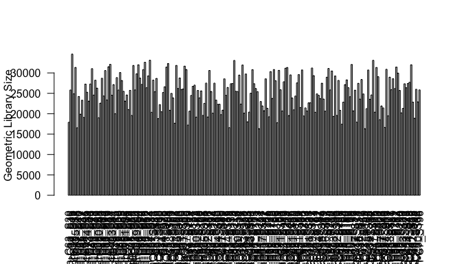

```r
barplot(Geo_Lib, xlab="Cell", las=2, ylab = "Geometric Library Size")
```

```r
lcounts <- log(counts + 1)
# PC1 and Geometric library size correlation
pc1 = irlba(lcounts - rowMeans(lcounts), 1)$v[,1] ## partial SVD
cor(Geo_Lib, pc1)
```

```
## [1] -0.9796015
```

## Run tSNE to cluster islet cells.

For comparison purposes, we applied tSNE on read counts of all genes. We used the Rtsne R package with default settings for this analyses. Genes are colored with respect to the expression of marker genes.

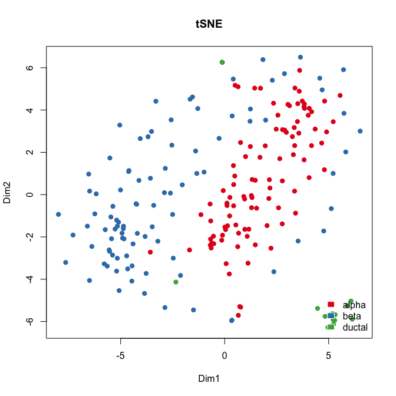

```r
set.seed(32354388)
tsne.res <- Rtsne(t(lcounts), dims = 2)
plot(tsne.res$Y, main="tSNE", xlab="Dim1", ylab="Dim2", pch=21,
     col=color.vec[Cell_Type], bg=color.vec[Cell_Type], oma=c(4,4,6,12))
legend("bottomright", levels(Cell_Type), border="white",fill=color.vec, bty="n")
```

## Run IA-SVA

Here, we first run IA-SVA using Patient_ID, Batch and Geo_Lib_Size as known factors and identify 5 hidden factors. Since cell type is not used as a known factor in this analyses, IA-SVA will detect the heterogeneity associated with the cell types.

```r
mod <- model.matrix(~Patient_ID+Batch+Geo_Lib)
summ_exp <- SummarizedExperiment(assays = counts)
iasva.res<- iasva(summ_exp, mod[,-1],verbose=FALSE, permute=FALSE, num.sv=5)
```

```
## IA-SVA running...
## SV1 Detected!
## SV2 Detected!
## SV3 Detected!
## SV4 Detected!
## SV5 Detected!
## # of significant surrogate variables: 5
```

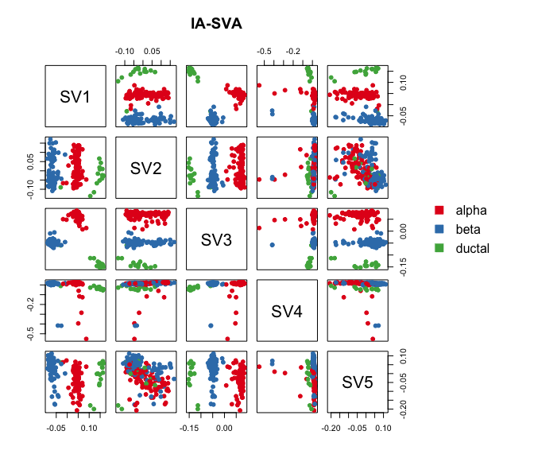

```r
iasva.sv <- iasva.res$sv

#with color-coding based on true cell-type
pairs(iasva.sv, main="IA-SVA", pch=21, col=color.vec[Cell_Type],
      bg=color.vec[Cell_Type], oma=c(4,4,6,14))
legend("right", levels(Cell_Type), border="white", fill=color.vec, bty="n")
```

```r
cor(Num_Detected_Genes, iasva.sv)
```

```
##              SV1        SV2         SV3        SV4       SV5
## [1,] -0.06492242 -0.6767266 -0.09183223 -0.1677585 0.7053465
```

```r
cor(Geo_Lib, iasva.sv)
```

```
##             SV1        SV2       SV3        SV4       SV5
## [1,] -0.2044236 -0.7212868 -0.275179 -0.1841835 0.7725583
```

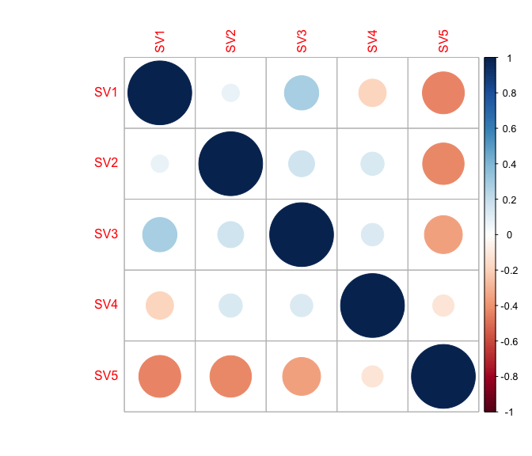

```r
corrplot(cor(iasva.sv))
```

## Find marker genes for SV1 and SV3.

Here, using the find_markers() function we find marker genes significantly associated with SV1 and SV3 (multiple testing adjusted p-value < 0.05, default significance cutoff, a high R-squared value: R-squared > 0.4).

```r
# try different R2 thresholds
pdf("Clustering_analyses_figure4_islets_sv1_3.pdf")
r2.results <- study_R2(summ_exp, iasva.sv,selected.svs=c(1,3), no.clusters=3)
```

```
## # of markers (SV1): 682
## # of markers (SV3): 534
## total # of unique markers:  979# of markers (SV1): 357
## # of markers (SV3): 281
## total # of unique markers:  519# of markers (SV1): 207
## # of markers (SV3): 161
## total # of unique markers:  309# of markers (SV1): 123
## # of markers (SV3): 99
## total # of unique markers:  192# of markers (SV1): 78
## # of markers (SV3): 62
## total # of unique markers:  129# of markers (SV1): 44
## # of markers (SV3): 37
## total # of unique markers:  79# of markers (SV1): 34
## # of markers (SV3): 26
## total # of unique markers:  58# of markers (SV1): 25
## # of markers (SV3): 20
## total # of unique markers:  44# of markers (SV1): 19
## # of markers (SV3): 14
## total # of unique markers:  33# of markers (SV1): 11
## # of markers (SV3): 9
## total # of unique markers:  20# of markers (SV1): 8
## # of markers (SV3): 7
## total # of unique markers:  15# of markers (SV1): 4
## # of markers (SV3): 7
## total # of unique markers:  11# of markers (SV1): 2
## # of markers (SV3): 5
## total # of unique markers:  7# of markers (SV1): 2
## # of markers (SV3): 3
## total # of unique markers:  5# of markers (SV1): 1
## # of markers (SV3): 3
## total # of unique markers:  4# of markers (SV1): 0
## # of markers (SV3): 1
## total # of unique markers:  1# of markers (SV1): 0
## # of markers (SV3): 0
## total # of unique markers:  0
```

```r
dev.off()
```

```r
marker.counts <- find_markers(summ_exp, as.matrix(iasva.sv[,c(1,3)])
                              , rsq.cutoff = 0.4)
```

```
## # of markers (SV1): 34
## # of markers (SV3): 26
## total # of unique markers:  58
```

```r
nrow(marker.counts)
```

```
## [1] 58
```

```r
anno.col <- data.frame(Cell_Type=Cell_Type)
rownames(anno.col) <- colnames(marker.counts)
head(anno.col)
```

```
##             Cell_Type
## 4th-C63_S30     alpha
## 4th-C66_S36     alpha
## 4th-C7_S15       beta
## 4th-C18_S31     alpha
## 4th-C5_S8        beta
## 4th-C57_S18     alpha
```

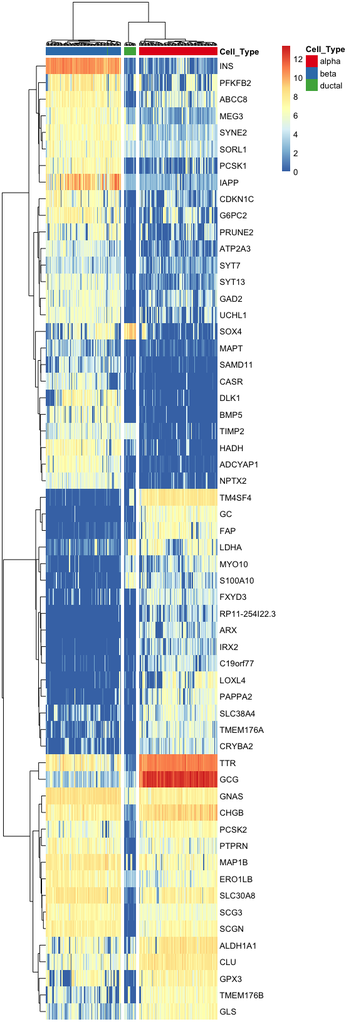

```r
cell.type.col <- color.vec[1:3]
names(cell.type.col) <- c("alpha","beta","ductal")
anno.colors <- list(Cell_Type=cell.type.col)

pheatmap(log(marker.counts+1), show_colnames =FALSE,
         clustering_method = "ward.D2", cutree_cols = 3,
         annotation_col = anno.col, annotation_colors = anno.colors)
```

In the case of islet cells, marker genes are well established and IA-SVA did an excellent job of redefining these markers along with some other highly informative genes. Therefore, IA-SVA can be effectively used to uncover heterogeneity associated with cell types and can reveal genes that are expressed in a cell-specific manner.

## Find marker genes for SV4.

Here, using the find_markers() function we find marker genes significantly associated with SV4 (multiple testing adjusted p-value < 0.05, default significance cutoff, a high R-squared value: R-squared > 0.3).

```r
marker.counts.SV4 <- find_markers(summ_exp, as.matrix(iasva.sv[,c(4)]),
                                  rsq.cutoff = 0.3)
```

```
## # of markers (): 94
## total # of unique markers:  94
```

```r
nrow(marker.counts.SV4)
```

```
## [1] 94
```

```r
anno.col <- data.frame(SV4=iasva.sv[,4])
rownames(anno.col) <- colnames(marker.counts)
head(anno.col)
```

```
##                      SV4
## 4th-C63_S30  0.022045049
## 4th-C66_S36  0.006979656
## 4th-C7_S15   0.014475352
## 4th-C18_S31  0.012836294
## 4th-C5_S8    0.009518166
## 4th-C57_S18 -0.126329593
```

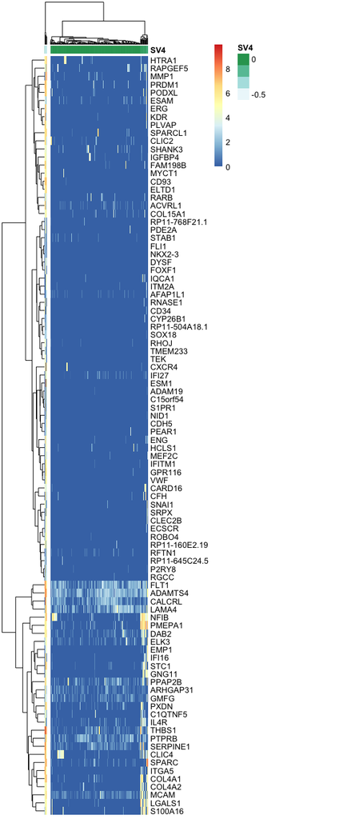

```r
pheatmap(log(marker.counts.SV4+1), show_colnames =FALSE,
         clustering_method = "ward.D2", cutree_cols = 2,
         annotation_col = anno.col)
```

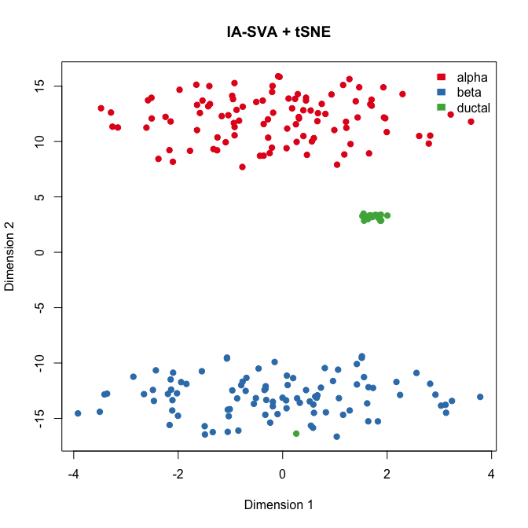

```r
set.seed(344588)
tsne.res.iasva <- Rtsne(unique(t(log(marker.counts+1))), dims = 2)
plot(tsne.res.iasva$Y, main="IA-SVA + tSNE", xlab="Dimension 1",
     ylab="Dimension 2", pch=21, col=color.vec[Cell_Type],
     bg=color.vec[Cell_Type], oma=c(4,4,6,12))
legend("topright", levels(Cell_Type), border="white", fill=color.vec, bty="n")
```

tSNE conducted on genes selected via IA-SVA very clearly seperates cells into their corresponding cell types. Moreover, this analyses also revealed one cell (green cell clustered together with blue cells) that is potentially mislabeled in the original analyses.

## Run CellView algorithm to visualize the data.

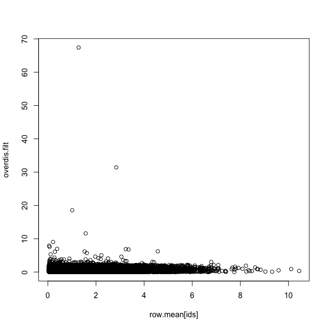

```r
# specify gene number to select for
gene_num <- 1000
# calcuclate dispersion
row.var <- apply(lcounts,1,sd)**2
row.mean <- apply(lcounts,1,mean)
dispersion <- row.var/row.mean

# generate sequence of bins
bins <- seq(from = min(row.mean), to = max(row.mean), length.out = 20)

# sort mean expression data into the bins
bin.exp <- row.mean
# sort the values
bin.sort <- sort(bin.exp, decreasing = FALSE)
# vector of bin assignment
cuts <- cut(x = bin.exp, breaks = bins, labels = FALSE)
# find which are NA and change to zero
na.ids <- which(is.na(cuts) == TRUE)
cuts[na.ids] <- 0

# create an empty vector for overdispersion
overdispersion <- NULL

# for each gene and bin index, calculate median, mad, and then normalized dispersion
# first loop through length of bins found
for (k in 1:length(names(table(cuts)))) {
  # find index of bins
  bin.id <- which(cuts == names(table(cuts))[k])
  # median of all genes in the bin
  median.bin <- median(dispersion[bin.id], na.rm = TRUE)
  # calculate mad (median absolute deviation)
  mad.bin <- mad(dispersion[bin.id])
  # calculate norm dispersion for each gene
  for (m in 1:length(bin.id)) {
    norm.dispersion <- abs(dispersion[bin.id[m]] - median.bin)/mad.bin
    overdispersion <- c(overdispersion, norm.dispersion)
  }
}

# remove nans
overdis.na <- which(is.na(overdispersion) == TRUE)
if (length(overdis.na) > 0) {
  overdis.filt <- overdispersion[-overdis.na]
} else {
  overdis.filt <- overdispersion
}

# plot mean expression vs overdisperssion
ids <- which(names(overdis.filt) %in% names(row.mean))
plot(row.mean[ids], overdis.filt)
```

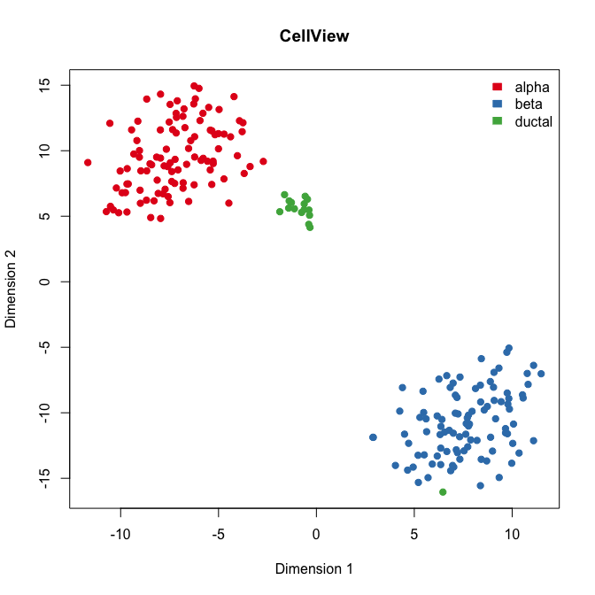

```r
# Do t-sne using top over-dispersed genes (apply mean expression filter too)
rank.ov <- order(overdis.filt, decreasing = TRUE)
ov.genes <- names(overdis.filt[rank.ov[1:gene_num]])
log.sel <- lcounts[ov.genes,]

all1 <- t(log.sel)
# Remove groups that are all zeros
df <- all1[,apply(all1, 2, var, na.rm=TRUE) != 0]

set.seed(34544532)
rtsne_out <- Rtsne(as.matrix(df), dims = 3)

# Set rownames of matrix to tsne matrix
rownames(rtsne_out$Y) <- rownames(df)

tsne.cellview <- rtsne_out$Y

plot(tsne.cellview[,c(1,2)], main="CellView", xlab="Dimension 1",
     ylab="Dimension 2",pch=21, col=color.vec[Cell_Type],
     bg=color.vec[Cell_Type], oma=c(4,4,6,12))
legend("topright", levels(Cell_Type), border="white", fill=color.vec, bty="n")
```

## Run Seurat to reduce dimensionality and visualize islet cells

```r
set.seed(12344)
seurat.obj <- CreateSeuratObject(raw.data=raw.counts,
                                 min.cells=3, min.genes=200, project="Seurat_Comp")

names(Patient_ID) <- rownames(seurat.obj@meta.data)
seurat.obj <- AddMetaData(object = seurat.obj,
                          metadata = Patient_ID, col.name = "patient.id")
names(Batch) <- rownames(seurat.obj@meta.data)
seurat.obj <- AddMetaData(object = seurat.obj,
                          metadata = Batch, col.name = "batch")
names(Geo_Lib) <- rownames(seurat.obj@meta.data)
seurat.obj <- AddMetaData(object = seurat.obj,
                          metadata = Geo_Lib, col.name = "geo.lib")

# Normalizing the data
seurat.obj <- NormalizeData(object = seurat.obj,
                            normalization.method = "LogNormalize",
                            scale.factor = median(colSums(raw.counts)))

# Detection of variable genes across the single cells
seurat.obj <- FindVariableGenes(object = seurat.obj,
                                mean.function = ExpMean, dispersion.function = LogVMR,
    x.low.cutoff = 0.0125, x.high.cutoff = 3, y.cutoff = 0.5)
```

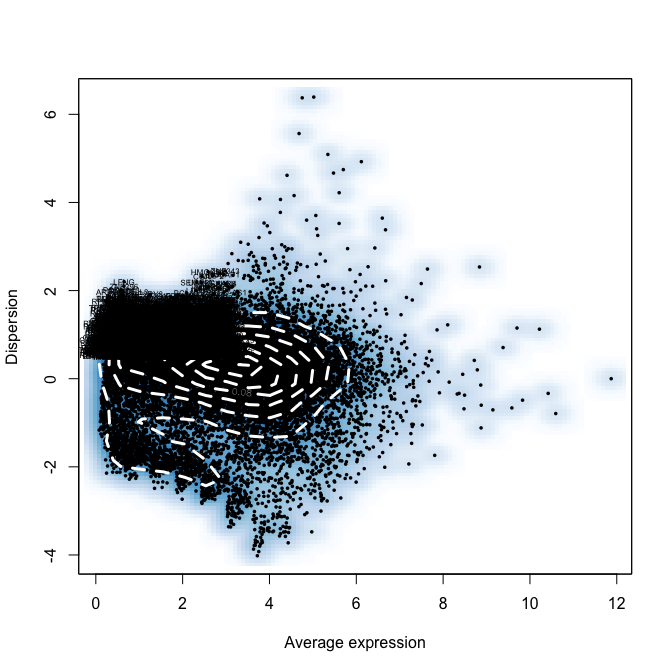

```r
length(x = seurat.obj@var.genes)
```

```
## [1] 2933
```

```r
# Scaling the data and removing unwanted sources of variation
seurat.obj <- ScaleData(object = seurat.obj,
                        vars.to.regress = c("patient.id", "batch", "geo.lib"))
```

```
## [1] "Regressing out patient.id" "Regressing out batch"
## [3] "Regressing out geo.lib"
##
## Time Elapsed:  33.1255159378052 secs
## [1] "Scaling data matrix"
##
```

```r
# Perform linear dimensional reduction
seurat.obj <- RunPCA(object = seurat.obj,
                     pc.genes = seurat.obj@var.genes,
                     do.print = TRUE, pcs.print = 1:5,
                     genes.print = 5)
```

```
## [1] "PC1"
## [1] "CCDC108"       "SGIP1"         "MBD5"          "RP11-222A11.1"
## [5] "GLRA3"
## [1] ""
## [1] "DEFB1" "VTCN1" "PKHD1" "ITGB6" "PROM1"
## [1] ""
## [1] ""
## [1] "PC2"
## [1] "ELTD1"  "GPR116" "ERG"    "VWF"    "DYSF"
## [1] ""
## [1] "VTCN1"  "DEFB1"  "PKHD1"  "ITGB6"  "LGALS4"
## [1] ""
## [1] ""
## [1] "PC3"
## [1] "PAQR4"   "SLITRK6" "BUB1B"   "MTFR2"   "TFAP2A"
```

[output cut: 17 more lines]

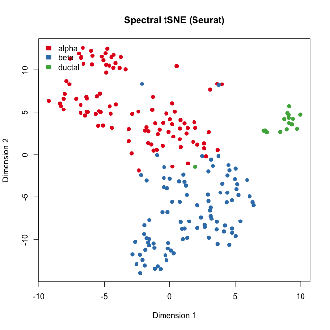

```r
# Run tSNE (Spectral tSNE)
set.seed(8883)
seurat.obj <- RunTSNE(object = seurat.obj, dims.use = 1:5, do.fast = TRUE)

# tSNE plot with color-coding of true cell types
plot(seurat.obj@dr$tsne@cell.embeddings[,c(1,2)],
     main="Spectral tSNE (Seurat)", xlab="Dimension 1",
     ylab="Dimension 2",pch=21, col=color.vec[Cell_Type],
     bg=color.vec[Cell_Type], oma=c(4,4,6,12))
legend("topleft", levels(Cell_Type), border="white", fill=color.vec, bty="n")
```

```r
pdf(file="Lawlor_Islets_3Cells_tSNE_IA-SVA_Fig4AB.pdf", width=9, height=5)
layout(matrix(c(1,2), nrow=1, ncol=2, byrow=TRUE))
plot(tsne.res$Y, main="tSNE", xlab="Dimension 1",
     ylab="Dimension 2", pch=21, col=color.vec[Cell_Type],
     bg=color.vec[Cell_Type])
legend("topleft", levels(Cell_Type), border="white",
       fill=color.vec, bty="n")
plot(tsne.res.iasva$Y, main="IA-SVA + tSNE", xlab="Dimension 1",
     ylab="Dimension 2", pch=21, col=color.vec[Cell_Type],
     bg=color.vec[Cell_Type])
legend("topright", levels(Cell_Type), border="white",
       fill=color.vec, bty="n")
dev.off()
```

```r
anno.col <- data.frame(Cell_Type=Cell_Type)
rownames(anno.col) <- colnames(marker.counts)
head(anno.col)
```

```
##             Cell_Type
## 4th-C63_S30     alpha
## 4th-C66_S36     alpha
## 4th-C7_S15       beta
## 4th-C18_S31     alpha
## 4th-C5_S8        beta
## 4th-C57_S18     alpha
```

```r
cell.type.col <- color.vec[1:3]
names(cell.type.col) <- c("alpha","beta","ductal")
anno.colors <- list(Cell_Type=cell.type.col)

pheatmap(log(marker.counts+1), show_colnames =FALSE,
         clustering_method = "ward.D2", cutree_cols = 3,
         annotation_col = anno.col, annotation_colors = anno.colors,
         filename="Lawlor_Islets_3Cells_IASVA_SV1SV3_rsqcutoff0.3_pheatmap_iasvaV0.95_Figure4_C.pdf",
         width=6, height=17)
```

```r
pdf(file="Lawlor_Islets_3Cells_IASVA_pairs4SVs_iasvaV0.95_black_FigS6.pdf",
    width=4, height=4)
pairs(iasva.sv[,1:4], pch=21, col="black", bg="black")
dev.off()
```

```r
pdf(file="Lawlor_Islets_3Cells_IASVA_pairs4SVs_iasvaV0.95_color_FigS6.pdf",
    width=4, height=4)
pairs(iasva.sv[,1:4], pch=21, col=color.vec[Cell_Type],
      bg=color.vec[Cell_Type])
dev.off()
```

```r
## 1,2
pdf(file="Lawlor_Islets_3Cells_CellView_Seurat_FigS.pdf", width=9, height=5)
layout(matrix(c(1,2), nrow=1, ncol=2, byrow=TRUE))
plot(tsne.cellview[,c(1,2)], main="CellView", xlab="Dimension 1",
     ylab="Dimension 2",pch=21, col=color.vec[Cell_Type],
     bg=color.vec[Cell_Type], oma=c(4,4,6,12))
legend("topright", levels(Cell_Type), border="white",
       fill=color.vec, bty="n")
plot(seurat.obj@dr$tsne@cell.embeddings[,c(1,2)],
     main="Spectral tSNE (Seurat)", xlab="Dimension 1",
     ylab="Dimension 2",pch=21, col=color.vec[Cell_Type],
     bg=color.vec[Cell_Type], oma=c(4,4,6,12))
legend("topleft", levels(Cell_Type), border="white",
       fill=color.vec, bty="n")
dev.off()
```

```r
write.table(as.data.frame(rownames(marker.counts)),
            file="Lawlor_Islets_3Cells_SV1_SV3_Cell_Type_Genes_rsqcutoff0.3.txt",
            quote=F, row.names=F, col.names=F, sep=" ")
```

```r
write.table(as.data.frame(rownames(marker.counts.SV4)),
            file="Lawlor_Islets_3Cells_SV4_Genes_rsqcutoff0.3.txt", quote=F,
            row.names=F, col.names=F, sep=" ")

anno.col <- data.frame(SV4=iasva.sv[,4])
rownames(anno.col) <- colnames(marker.counts)
head(anno.col)
```

```
##                      SV4
## 4th-C63_S30  0.022045049
## 4th-C66_S36  0.006979656
## 4th-C7_S15   0.014475352
## 4th-C18_S31  0.012836294
## 4th-C5_S8    0.009518166
## 4th-C57_S18 -0.126329593
```

```r
pheatmap(log(marker.counts.SV4+1), show_colnames =FALSE,
         clustering_method = "ward.D2", cutree_cols = 2,
         annotation_col = anno.col,
         filename="Lawlor_Islets_3Cells_IASVA_SV4_rsqcutoff0.3_pheatmap_iasvaV0.95.pdf",
         width=8, height=14)
```